# FTAP Homework 2

Zachary Fogelson

July 14, 2015

### Problem 1: Compute Variance and Covariance Matrixes

- Code:

```r
countries <- read.xls(xls = "country portfolios.xlsx", sheet = 1)
countries <- rename(x = countries, c("Global.Index.Key...Index.Monthly"="key", "Index.Price...Close.Monthly"="price", "Data.Date...Index.Monthly"="date", "Index.Name"="name"))

indexReturns <- data.frame(seq(1:184))

for(i in unique(countries$name)){

  considering <- countries[countries["name"] == i,]
  diff <- considering$price[-1] - considering$price[-length(considering$price)]
  basicReturn <- diff / considering$price[-length(considering$price)]
  indexReturns <- cbind(indexReturns, basicReturn)
  indexReturns <- rename(x = indexReturns, c("basicReturn"=i))
}
drops <- c("seq.1.184.")
indexReturns <- indexReturns[, !(names(indexReturns) %in% drops)]
```

- Variance Covariance Matrix

```r
varCov <- var(indexReturns, y=indexReturns)
kable(head(varCov, n = 5))
```

|  | Composite DAX Index | FTSE 100 Index | Madrid Stock Exchange Index | Australian All Ordinary Index | Nikkei 225 Index | Brazilian Bovespa Index | CAC 40 Index | Bombay Stock Exchange Sensitive Index | IBEX 35 Index | S&P 500 Comp-Ltd |
| --- | --- | --- | --- | --- | --- | --- | --- | --- | --- | --- |
| Composite DAX Index | 0.0036176 | 0.0019738 | 0.0025917 | 0.0015351 | 0.0019419 | 0.0026458 | 0.0028844 | 0.0023460 | 0.0027145 | 0.0021130 |
| FTSE 100 Index | 0.0019738 | 0.0016085 | 0.0016499 | 0.0011081 | 0.0013110 | 0.0018695 | 0.0018158 | 0.0015302 | 0.0017123 | 0.0015059 |
| Madrid Stock Exchange Index | 0.0025917 | 0.0016499 | 0.0032436 | 0.0013446 | 0.0017166 | 0.0024405 | 0.0024252 | 0.0021216 | 0.0033456 | 0.0017228 |
| Australian All Ordinary Index | 0.0015351 | 0.0011081 | 0.0013446 | 0.0013952 | 0.0012771 | 0.0017591 | 0.0013914 | 0.0015663 | 0.0013775 | 0.0012024 |
| Nikkei 225 Index | 0.0019419 | 0.0013110 | 0.0017166 | 0.0012771 | 0.0032534 | 0.0019159 | 0.0017033 | 0.0022076 | 0.0017686 | 0.0015222 |

- Correlation Matrix

```r
corMat <- cor(indexReturns, indexReturns)
kable(head(corMat, n=5))
```

|  | Composite DAX Index | FTSE 100 Index | Madrid Stock Exchange Index | Australian All Ordinary Index | Nikkei 225 Index | Brazilian Bovespa Index | CAC 40 Index | Bombay Stock Exchange Sensitive Index | IBEX 35 Index | S&P 500 Comp-Ltd |
| --- | --- | --- | --- | --- | --- | --- | --- | --- | --- | --- |
| Composite DAX Index | 1.0000000 | 0.8182508 | 0.7566041 | 0.6832726 | 0.5660296 | 0.6039706 | 0.9232207 | 0.5562111 | 0.7653119 | 0.8054211 |
| FTSE 100 Index | 0.8182508 | 1.0000000 | 0.7223374 | 0.7396863 | 0.5730832 | 0.6400278 | 0.8716049 | 0.5440787 | 0.7239827 | 0.8608577 |
| Madrid Stock Exchange Index | 0.7566041 | 0.7223374 | 1.0000000 | 0.6320694 | 0.5284373 | 0.5883686 | 0.8197937 | 0.5312397 | 0.9961636 | 0.6935291 |
| Australian All Ordinary Index | 0.6832726 | 0.7396863 | 0.6320694 | 1.0000000 | 0.5994450 | 0.6466089 | 0.7171355 | 0.5979840 | 0.6253715 | 0.7380368 |
| Nikkei 225 Index | 0.5660296 | 0.5730832 | 0.5284373 | 0.5994450 | 1.0000000 | 0.4611841 | 0.5748808 | 0.5519168 | 0.5257944 | 0.6118630 |

**(a)** The correlation matrix contains more interpretable information regarding the degree of co-movement in each pair of series because it is normalized based on the standard deviations

**(b)**

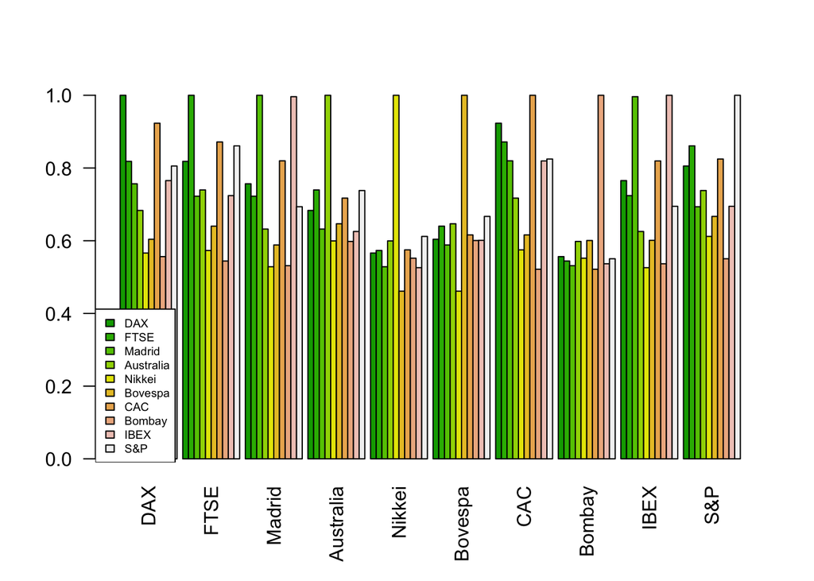

```r
labs <- c("DAX", "FTSE", "Madrid", "Australia", "Nikkei", "Bovespa", "CAC", "Bombay", "IBEX", "S&P")
bar <- barplot(as.matrix(corMat), beside = T, col = terrain.colors(length(names(corMat[,1]))), las = 2, names.arg = labs)
legend("bottomleft",labs, cex=0.6, fill=terrain.colors(10))
```

Based on the barplot one can clearly see that the cac40 and the FTSE 100 and the Composite DAX index are highly correlated, which makes sense given that we saw in class that European economic performance is highly correlated.

### Problem 2

| $x_i$ / $x_{i+1}$ | $x_i = 0$ | $x_i = 1$ | $x_{i+1}$ Marginal |
| --- | --- | --- | --- |
| $x_{i+1} = 0$ | .3 | .2 | .5 |
| $x_{i+1} = 1$ | .2 | .3 | .5 |
| $x_{i}$ Marginal | .5 | .5 | 1 |

**(b)** Trades are positively correlated becaues the probabilities along the diagonal of similar outcomes between $x_i$ and $x_{i+1}$ are high.

**(c)** Because the marginal probabilities for $x_i$ and $x_{i+1}$ (seen in the table above) are the same they are identically distributed. Their distrobutions are both (0 -> .5, 1 -> .5)

**(d)** .5

**(e)** $P(x_{i+1} = 1|x_i = 1) = \frac{.3}{.5} = .6$

**(f)** $P(x_{i+1} = 0|x_i = 1) = \frac{.2}{.5} = .4$

**(g)**

| Outcomes | $P(x_{i+1}\|x_i=1)$ |
| --- | --- |
| $0$ | .4 |
| $1$ | .6 |

**(h)**

| Outcomes | $P(x_{i+1}\|x_i=0)$ |
| --- | --- |
| $0$ | .6 |
| $1$ | .4 |

**(i)** Buys tend to follow buys and sells tend to follow sells.

**(j)** $P(1,0,0,1,1,1,0) = (.5)(.4)(.6)(.4)(.6)(.6)(.4) = .006912$

**(k)** Conditional on the previous trade having been a buy the probability will increase for the particular series of buys and sells. $P(1,0,0,1,1,1,0) = (.6)^4(.4)^3 = .008294$

### Problem 3

$y_t = y_{t-1} + x_t$

$y_{t-1} = 100$

**(a)** No, $y$ is not an iid process because it depends on the previous value in the sequence and therefore the values one would expect for $y$ are not consistent overtime.

**(b)**

| Outcomes | $P(y_t)$ |
| --- | --- |
| 102 | .1 |
| 101 | .25 |
| 100 | .3 |
| 99 | .25 |
| 98 | .1 |

**(c)** The distrobution of $y_t$ is the same because we do not have any knowledge besides $y_{t-1}$ and the distrobution of $x_t$.

**(d)**

$P(y_t>101) = .1$

$P(y_t<100) = .35$

$P(y_t>101) + P(y_t<100) = .45$

**(e)**

| Outcomes | $P(y_t)$ |
| --- | --- |
| 104 | .01 |
| 103 | .05 |
| 102 | .12 |
| 101 | .2 |
| 100 | .24 |
| 99 | .2 |
| 98 | .12 |
| 97 | .05 |
| 96 | .01 |

**(f)**

$P(y_t>101) = .18$

$P(y_t<100) = .38$

$P(y_t>101) + P(y_t<100) = .56$

### Problem 4

$x_t$ is a randome variable $\therefore$ $E[c_0 + c_1x_t] = c_0 + c_1 E[x_t]$ $Var[c_0 + c_1x_t] = c_1^2 Var[x_t]$

Because of $y_t$ is a linear function applied to $x_t$ it also is a normal random variable with a mean of $y_{t-1} + .01$ and $\sigma = .04$

($N(y_{t-1} + .01, .04^2)$)

### Problem 5

Model for X

- X appears to be an iid model. Based on the data set, possible states are:

| Outcomes | $P(X)$ |
| --- | --- |
| 4 | .18 |
| 3 | .35 |
| 2 | .28 |
| 1 | .19 |

Model for Y

- Y appears to be a random walk model
- $y_t = y_{t-1} + z$ where $z$ is an iid

| Outcomes | $P(z)$ |
| --- | --- |
| -.02 | .13 |
| -.01 | .26 |
| 0 | .28 |
| .01 | .24 |
| .02 | .08 |

### Problem 6

| $x$ / $y$ | $x = 0$ | $x = .05$ | $x = .1$ |
| --- | --- | --- | --- |
| $y = 0$ | .1 | .15 | .05 |
| $y = .05$ | .15 | .2 | .1 |
| $y = .1$ | .05 | .1 | .1 |
| $x$ Marginal | .3 | .45 | .25 |

**(a)**

| $x$ | $P(x)$ |
| --- | --- |
| 0 | .3 |
| .05 | .45 |
| .1 | .25 |

| $y$ | $P(y)$ |
| --- | --- |
| 0 | .3 |
| .05 | .45 |
| .1 | .25 |

**(b)**

$P(X = 0) \stackrel{?}{\ne} P(X = 0| Y=0)$

$.3 P(X = 0) \stackrel{?}{\ne} .1/.3$

$.3 \ne 1/3$

The variables are dependent.

**(c)** Yes

**(d)** $\mu_{x,y} = .3 * 0 + .45 * .05 + .25 * .1 = .0475$

$Var(x) = E[X^2] + E[X]^2 = .45 * (.05)^2 + .25 *(.1)^2 - .0475^2 = .00136875$

**(e)**

$(0-.0475)*(.1*(0-.0475) + .15*(.05 - -.0475) + .05*(.1-.0475)) + (.05-.0475)*(.15*(0-.0475) \\ + .2*(.05 - -.0475) + .1*(.1-.0475) )+ (.1 -.0475)*(.05*(0-.0475) + .1*(.05 - -.0475) + \\ .1*(.1-.0475)) = .0002406$

**(f)**

| $Y$ | $P(Y\|X=.1)$ |
| --- | --- |
| 0 | .2 |
| .05 | .4 |
| .1 | .4 |

**(h)**

$E[Y|X=.1] = .06$

**(i)** The condistional expected value makes sense because when X is high so is Y.

### Problem 7

$Y = \frac{1}{m}S_1 + \ldots + \frac{1}{m}S_m$

$Var(Y) = \frac{1}{m}^2S_1^2 + \ldots + \frac{1}{m}^2S_m^2 + 2 * [(\frac{1}{m}^2) \rho \sigma^2 \ldots (\frac{1}{m}^2) \rho \sigma^2]$

$Var(Y) = m(\frac{1}{m}^2S_1^2) + 2 * {m \choose 2}[(\frac{1}{m}^2) \rho \sigma^2]$

$Var(Y) = \frac{1}{m}S_1^2 + m(m-1) ((\frac{1}{m}^2) \rho \sigma^2)$

$Var(Y) = \frac{1}{m}S_1^2 + \rho \sigma^2 - \frac{1}{m}\rho \sigma^2$

**(a)** When m is large $Var(Y) = \rho \sigma^2$

**(b)** $\sigma^2$

**(c)** 0

### Problem 8

**(a)**

$\mu_{.3,.7} = .3 * (.06) + .7*(.11) = .095$

$S_{.3,.7} = .7^2 * .15^2 + .3^2 * .08^2 + 2 * .7 * .3 *.0024 = .013$

$N(.095, .0126)$

**(b)**

$\mu_{.5,.5} = .5 * (.06) + .5*(.11) = .085$

$S_{.5,.5} = .5^2 * .15^2 + .5^2 * .08^2 + 2 * ..5^2 *.0024 = .0084$

$N(.085, .0084)$

**(c)**

$.085 - 5 * .0084 > .095 - 5 * .013 \therefore$ the investor will choose the (.5,.5) weighted portfolio

### Problem 9

**(a)**

$E[Y] = nP$

$10 * 10 * .6 = \$60$

**(b)**

$Var(Y) = n*p(1-p)$

### Problem 10

$\mu = \$10,000$ $\sigma = \$40,000$

**(a)** $X_i = $ Profits of the ith year

$Y = X_1 + \ldots + X_20$

**(b)** The distrobution of $Y$ should be normal

**(c)** pnorm(-20,000, 10,000, 40,000) = 22.66%

### Problem 11

**(a)**

$E[X] = .1*2 + .25 * 1 _ .3 * 0 + .25 * -1 + .1 * -2 = 0$

$Var[X] = E[X^2] - E[X]^2 = 1.3$

**(b)** $w_t = y_t - y_0$ $w_t = (y_t - y_{t-1}) + \ldots + (y_1 - y_0)$ Substitute $y_i = y_{i-1} + x_i$ $w_t = x_t + \ldots + x_0$ $E[w_t] = E[x_t + \ldots + x_0] = t * (E[X]) = 0$ $Var[w_t] = t^2 Var[X] = 1.3*t^2$

**(c)** $N(0, 1.3t^2)$